# ch07_item_based01

### 아이템 기반 협업 필터링 영화 추천

### 데이터 셋

- MovieLens 100K Dataset
- url : https://grouplens.org/datasets/movielens/100k/
- u.data
  - user_id : 유저 정보
  - item_id : 영화 정보
  - ratings : 평점 정보
  - timestamp : 시간 정보

```python
import pandas as pd
import numpy as np
import sklearn
from sklearn.decomposition import TruncatedSVD
from IPython.display import display, Image
```

### 데이터 불러오기

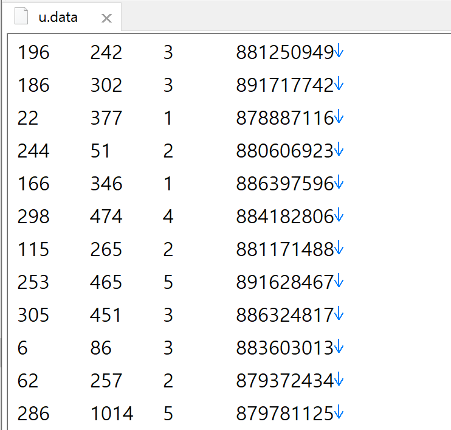

```python
display(Image(filename='data_u_data.png'))
```

```python
columns = ['user_id', 'item_id', 'rating', 'timestamp']
df = pd.read_csv('../data/ml-100k/u.data', sep='\t', names=columns)
print(df.shape)
df.head()
```

```
(100000, 4)
```

|  | user_id | item_id | rating | timestamp |
| --- | --- | --- | --- | --- |
| 0 | 196 | 242 | 3 | 881250949 |
| 1 | 186 | 302 | 3 | 891717742 |
| 2 | 22 | 377 | 1 | 878887116 |
| 3 | 244 | 51 | 2 | 880606923 |
| 4 | 166 | 346 | 1 | 886397596 |

### 데이터 정보

- 파일명 : u.u_item
  - item_id : 영화 정보
  - movie title : 영화 제목
  - release date : 출시일
  - video release date : 비디오 출시일
  - IMDb URL : IMDb URL 정보
  - unkonwn, ... : 기타 장르 정보

[figure not shown]

```python
display(Image(filename='data_u_item.png'))
```

```python
# 장르 분야
columns = ['item_id', 'movie title', 'release date', 'video release date', 'IMDb URL',
           'unknown', 'Action', 'Adventure', 'Animation', 'Childrens',
           'Comedy', 'Crime', 'Documentary', 'Drama', 'Fantasy',
           'Film-Noir', 'Horror', 'Musical', 'Mystery', 'Romance',
           'Sci-Fi', 'Thriller', 'War', 'Western']

movies = pd.read_csv('../data/ml-100k/u.item', sep='|', names=columns, encoding='latin-1')

movie_names = movies[['item_id', 'movie title']]
c_movies_data = pd.merge(df, movie_names, on='item_id')
print(c_movies_data.shape)
c_movies_data.head()
```

```
(100000, 5)
```

|  | user_id | item_id | rating | timestamp | movie title |
| --- | --- | --- | --- | --- | --- |
| 0 | 196 | 242 | 3 | 881250949 | Kolya (1996) |
| 1 | 63 | 242 | 3 | 875747190 | Kolya (1996) |
| 2 | 226 | 242 | 5 | 883888671 | Kolya (1996) |
| 3 | 154 | 242 | 3 | 879138235 | Kolya (1996) |
| 4 | 306 | 242 | 5 | 876503793 | Kolya (1996) |

### 사용자-아이템 표 만들기

- 우리의 데이터에 대해 pivot를 사용해본다.
- 빈 값은 0으로 채우기

```python
rating_crosstab = c_movies_data.pivot_table(values='rating',
                                            index='user_id',
                                            columns='movie title', fill_value=0)
rating_crosstab.head()
```

| movie title user_id | 'Til There Was You (1997) | 1-900 (1994) | 101 Dalmatians (1996) | 12 Angry Men (1957) | 187 (1997) | 2 Days in the Valley (1996) | 20,000 Leagues Under the Sea (1954) | 2001: A Space Odyssey (1968) | 3 Ninjas: High Noon At Mega Mountain (1998) | 39 Steps, The (1935) | ... | Yankee Zulu (1994) | Year of the Horse (1997) | You So Crazy (1994) | Young Frankenstein (1974) | Young Guns (1988) | Young Guns II (1990) | Young Poisoner's Handbook, The (1995) | Zeus and Roxanne (1997) | unknown | Á köldum klaka (Cold Fever) (1994) |
| --- | --- | --- | --- | --- | --- | --- | --- | --- | --- | --- | --- | --- | --- | --- | --- | --- | --- | --- | --- | --- | --- |
| 1 | 0 | 0 | 2 | 5 | 0 | 0 | 3 | 4 | 0 | 0 | ... | 0 | 0 | 0 | 5 | 3 | 0 | 0 | 0 | 4 | 0 |
| 2 | 0 | 0 | 0 | 0 | 0 | 0 | 0 | 0 | 1 | 0 | ... | 0 | 0 | 0 | 0 | 0 | 0 | 0 | 0 | 0 | 0 |
| 3 | 0 | 0 | 0 | 0 | 2 | 0 | 0 | 0 | 0 | 0 | ... | 0 | 0 | 0 | 0 | 0 | 0 | 0 | 0 | 0 | 0 |
| 4 | 0 | 0 | 0 | 0 | 0 | 0 | 0 | 0 | 0 | 0 | ... | 0 | 0 | 0 | 0 | 0 | 0 | 0 | 0 | 0 | 0 |
| 5 | 0 | 0 | 2 | 0 | 0 | 0 | 0 | 4 | 0 | 0 | ... | 0 | 0 | 0 | 4 | 0 | 0 | 0 | 0 | 4 | 0 |

5 rows × 1664 columns

### 아이템 기반 협업 필터링을 위해 행열 바꾸기

```python
X = rating_crosstab.T
print(X.shape)
```

```
(1664, 943)
```

### SVD

- 사이킷런을 활용하여 SVD를 할수 있다.
- truncated SVD를 사용하여 차원 축소

```python
SVD = TruncatedSVD(n_components=12, random_state=5)
resultant_matrix = SVD.fit_transform(X)
resultant_matrix.shape
```

```
(1664, 12)
```

- 1664개 행과 잠재변수 12개의 열를 갖는 행렬 생성

### Correlation Pearson

- 피어슨 상관계수 , 코사인 유사성과 같은 다양한 유사성 측정 지표를 사용할 수 있다.
- 피어슨 상관계수를 이용하여 상관 행렬을 만들어봄.

```python
### correlation matrix
corr_mat = np.corrcoef(resultant_matrix)
print( corr_mat.shape )
corr_mat
```

```
(1664, 1664)
```

```
array([[ 1.        , -0.11573577,  0.51362284, ...,  0.38310045,
         0.20193733,  0.5065142 ],
       [-0.11573577,  1.        ,  0.05820808, ...,  0.15805829,
         0.51795357,  0.27104818],
       [ 0.51362284,  0.05820808,  1.        , ...,  0.76575655,
         0.43824619,  0.19507139],
       ...,
       [ 0.38310045,  0.15805829,  0.76575655, ...,  1.        ,
         0.18043708,  0.12115972],
       [ 0.20193733,  0.51795357,  0.43824619, ...,  0.18043708,
         1.        ,  0.20126072],
       [ 0.5065142 ,  0.27104818,  0.19507139, ...,  0.12115972,
         0.20126072,  1.        ]])
```

### Similar Movies to Star Wars (1977)

```python
rating_crosstab.columns.get_loc("Star Wars (1977)")
```

```
1398
```

```python
col_idx = rating_crosstab.columns.get_loc("Star Wars (1977)")
corr_specific = corr_mat[col_idx]    # Star Wars (1977)의 위치 행 획득
print(corr_specific.shape)
```

```
(1664,)
```

```python
result = pd.DataFrame({'corr_specific':corr_specific, 'Movies': rating_crosstab.columns})
print(result.shape)
result.head()
```

```
(1664, 2)
```

|  | corr_specific | Movies |
| --- | --- | --- |
| 0 | 0.357238 | 'Til There Was You (1997) |
| 1 | 0.421507 | 1-900 (1994) |
| 2 | 0.593815 | 101 Dalmatians (1996) |
| 3 | 0.722361 | 12 Angry Men (1957) |
| 4 | 0.325221 | 187 (1997) |

### 10개의 영화 추천

```python
result.sort_values('corr_specific', ascending=False).head(10)
```

|  | corr_specific | Movies |
| --- | --- | --- |
| 1398 | 1.000000 | Star Wars (1977) |
| 1234 | 0.988052 | Return of the Jedi (1983) |
| 1460 | 0.942655 | Terminator 2: Judgment Day (1991) |
| 1523 | 0.933978 | Toy Story (1995) |
| 1461 | 0.931701 | Terminator, The (1984) |
| 1205 | 0.925185 | Raiders of the Lost Ark (1981) |
| 456 | 0.923562 | Empire Strikes Back, The (1980) |
| 570 | 0.915965 | Fugitive, The (1993) |
| 414 | 0.914299 | Die Hard (1988) |
| 44 | 0.892894 | Aliens (1986) |

### (실습) Godfather, The (1972)에 대한 10개의 영화 추천해 보기

```python
col_idx = rating_crosstab.columns.get_loc("Godfather, The (1972)")
corr_specific = corr_mat[col_idx]    # Godfather, The (1972)의 위치 행 획득
print(corr_specific.shape)
```

```
(1664,)
```

```python
result = pd.DataFrame({'corr_specific':corr_specific, 'Movies': rating_crosstab.columns})
result.sort_values('corr_specific', ascending=False).head(10)
```

|  | corr_specific | Movies |
| --- | --- | --- |
| 612 | 1.000000 | Godfather, The (1972) |
| 613 | 0.921444 | Godfather: Part II, The (1974) |
| 498 | 0.921420 | Fargo (1996) |
| 623 | 0.900758 | GoodFellas (1990) |
| 237 | 0.865385 | Bronx Tale, A (1993) |
| 1398 | 0.865148 | Star Wars (1977) |
| 209 | 0.864269 | Boot, Das (1981) |
| 389 | 0.857308 | Dead Man Walking (1995) |
| 622 | 0.845558 | Good, The Bad and The Ugly, The (1966) |
| 1190 | 0.842705 | Pulp Fiction (1994) |

- 우리는 Godfather의 영화를 좋아하는 사람이 있다면 Godfather: Part II, Star Wars (1977)를 볼 것을 제안할 수 있다.
- 역으로 Godfather의 영화를 피하는 사람이라면 Godfather: Part II, Star Wars (1977) 를 피할 것을 제안할 수 있다.

### 실습해 보기

- Pulp Fiction (1994) 에 대한 유사 영화 10개를 추천해 보자.

### History

- 2021-10 ver 01